# DataProjectR9Shiny

[figure not shown]

The most salient pattern is that gas usage, both residential and commercial, exhibits the greatest variation between the cold Winter months and the warm Summer months with its use spiking greatly in the Winter months especially for residential use. This pattern in gas usage seems have held true this year during the COVID-19 pandemic.

The primary difference in energy consumption before and after the beginning of the COVID-19 pandemic seems to come from slight differences in electrical usage. Comparing 2020 electric usage to prior years, there seems to have been an overall increase in residential electric usage in Quarters 2 and 3 compared to prior years. Similarly, there seems to have been an overall decrease in commercial electric usage in Quarters, 1, 2, and 3 compared to prior years. This trend is significant enough that by Quarter 3 of 2020, the residential and commercial electric usage reach near parity whereas for prior years, commerical electric usage maintains a decently greater level than residential electric usage.

This makes sense as, since the COVID-19 safety restrictions and lockdowns were put into place, a significantly greater number of Bay Area residents would be staying in their homes rather than spending time in commercial zones eating at restaurants or shopping at stores. Thus, Bay Area residents are now consuming more energy from their homes while the businesses in the commerical district are not staying open as late, not getting as much traffic, may be going out of business, or may be temporarily closed.

### Electricity Usage data

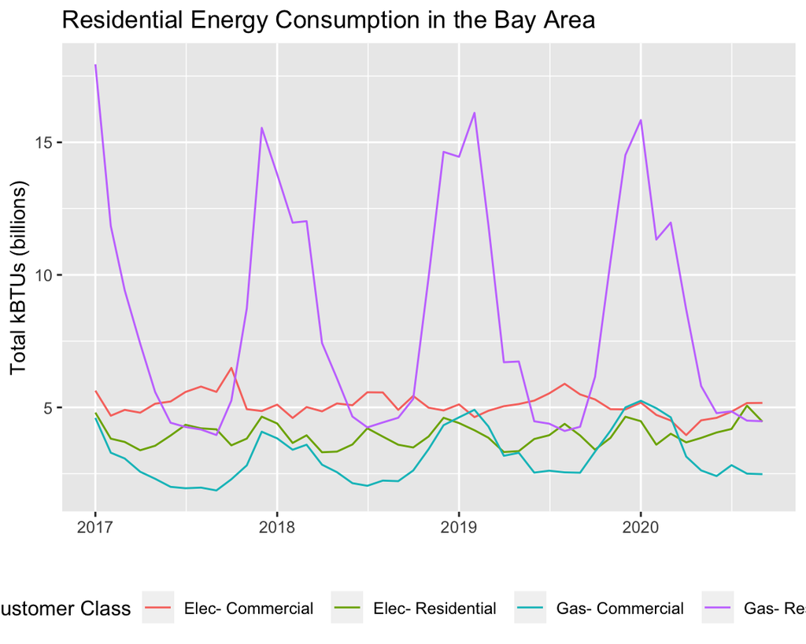

Overall, most every neighborhood in the Bay Area saw an increase in their residential electricity consumption. This increase was typically between 5% and 15%. Very few locations experienced a decrease.

One of these locations, which reports a -68% change in kBTU total, is located in Oakland, Alameda couny. However, considering how stark of a decrease this is, especially compared with the moderate increases in electric usage in every locality surrounding it, it is possible that this may be a result of the data being misreported. Unless there is some outstanding factor affecting this locality, it is very unlikely that its change in residential electricity usage differs so greatly from, in fact, all other localities in the Bay Area.

There are also a pair of two localities in Sonoma county which report sizeable decreases in kBTU residential electricity usage along with a few other localities in Marin and Sonoma counties with much smaller decreases. Considering the more moderate decreases in these localities compared to the Oakland locality, this is less suspect of data error. The reason for their decrease, however, is unknown to me. Perhaps these are localities which have a high number of second homes for wealthier residents of the Bay Area and, because of COVID-19, for one reason or another, these wealthy residents are not travelling to these second homes.

### Change in Residential Electric Usage

[interactive chart not shown]